# Analysis of weather events which most harmful with respect to population health and have the greatest economic consequences across the United States.

Nariman Daniyarov

25 12 2020

Storms and other severe weather events can cause both public health and economic problems for communities and municipalities. Many severe events can result in fatalities, injuries, and property damage, and preventing such outcomes to the extent possible is a key concern.  
The basic goal of this project is to explore the NOAA Storm Database and answer next basic questions:  
1. Across the United States, which types of events (as indicated in the EVTYPE variable) are most harmful with respect to population health?  
2. Across the United States, which types of events have the greatest economic consequences?  
The data for this project come in the form of a comma-separated-value file compressed via the bzip2 algorithm to reduce its size. This database tracks characteristics of major storms and weather events in the United States, including when and where they occur, as well as estimates of any fatalities, injuries, and property damage.  
For this project we use some functions from dplyr package. Also, for plotting we use ggplot2 library.

## Data Processing

Include required libraries

```r
library(dplyr)
library(ggplot2)
```

The data can be download as follow:

```r
data_url <- "https://d396qusza40orc.cloudfront.net/repdata%2Fdata%2FStormData.csv.bz2"
data_file <- "repdata_data_StormData.csv.bz2"

if(!file.exists(data_file)) {
        download.file(data_url, data_file, mode = "wb")
}
```

Read the downloaded data:

```r
raw_data <- read.csv(data_file, header = TRUE)
```

```r
data_dim <- dim(raw_data)
```

Data has **902297** observations and **37** variables.

For further work with data, we need to display a list of column names

```r
colnames(raw_data)
```

```
##  [1] "STATE__"    "BGN_DATE"   "BGN_TIME"   "TIME_ZONE"  "COUNTY"
##  [6] "COUNTYNAME" "STATE"      "EVTYPE"     "BGN_RANGE"  "BGN_AZI"
## [11] "BGN_LOCATI" "END_DATE"   "END_TIME"   "COUNTY_END" "COUNTYENDN"
## [16] "END_RANGE"  "END_AZI"    "END_LOCATI" "LENGTH"     "WIDTH"
## [21] "F"          "MAG"        "FATALITIES" "INJURIES"   "PROPDMG"
## [26] "PROPDMGEXP" "CROPDMG"    "CROPDMGEXP" "WFO"        "STATEOFFIC"
## [31] "ZONENAMES"  "LATITUDE"   "LONGITUDE"  "LATITUDE_E" "LONGITUDE_"
## [36] "REMARKS"    "REFNUM"
```

#### **Question 1. Across the United States, which types of events (as indicated in the EVTYPE variable) are most harmful with respect to population health?**

**For purpose of this, we have to subset the data by selecting three columns**

```r
hd_data <- select(raw_data, EVTYPE,  FATALITIES, INJURIES)
head(hd_data)
```

```
##    EVTYPE FATALITIES INJURIES
## 1 TORNADO          0       15
## 2 TORNADO          0        0
## 3 TORNADO          0        2
## 4 TORNADO          0        2
## 5 TORNADO          0        2
## 6 TORNADO          0        6
```

**Check for NAs on FATALITIES and INJURIES columns**

```r
colSums(is.na(select(hd_data, FATALITIES, INJURIES)))
```

```
## FATALITIES   INJURIES
##          0          0
```

**Group data by severe weather types, then summarise values on FATALITIES and INJURIES**

```r
hd_data <- hd_data %>%
                group_by(EVTYPE) %>%
                summarise(FATALITIES = sum(FATALITIES), INJURIES = sum(INJURIES))
head(hd_data)
```

```
## # A tibble: 6 x 3
##   EVTYPE                  FATALITIES INJURIES
##   <chr>                        <dbl>    <dbl>
## 1 "   HIGH SURF ADVISORY"          0        0
## 2 " COASTAL FLOOD"                 0        0
## 3 " FLASH FLOOD"                   0        0
## 4 " LIGHTNING"                     0        0
## 5 " TSTM WIND"                     0        0
## 6 " TSTM WIND (G45)"               0        0
```

**Now we should get the total health damage by summing values on FATALITIES and INJURIES columns, and store the results on new columns HEALTHDMG, and perform sorting on descending order**

```r
hd_data <- hd_data %>%
        mutate(HEALTHDMG = FATALITIES + INJURIES) %>%
        select(EVTYPE, HEALTHDMG) %>%
        arrange(desc(HEALTHDMG))
head(hd_data, 10)
```

```
## # A tibble: 10 x 2
##    EVTYPE            HEALTHDMG
##    <chr>                 <dbl>
##  1 TORNADO               96979
##  2 EXCESSIVE HEAT         8428
##  3 TSTM WIND              7461
##  4 FLOOD                  7259
##  5 LIGHTNING              6046
##  6 HEAT                   3037
##  7 FLASH FLOOD            2755
##  8 ICE STORM              2064
##  9 THUNDERSTORM WIND      1621
## 10 WINTER STORM           1527
```

**Percentage of the TOP-10 amount in the total amount**

```r
percentage_of_top_10 <- sum(hd_data[1:10,"HEALTHDMG"]) / sum(hd_data[,"HEALTHDMG"]) * 100
```

**We should subset only first 10 harmful weather events to construct a graph**

```r
hd_data <- hd_data[1:10,] # selected only first 10 rows
dim(hd_data)
```

```
## [1] 10  2
```

**Constructing a graph to determine which severe weather events are most harmful with respect to population health across the USA**

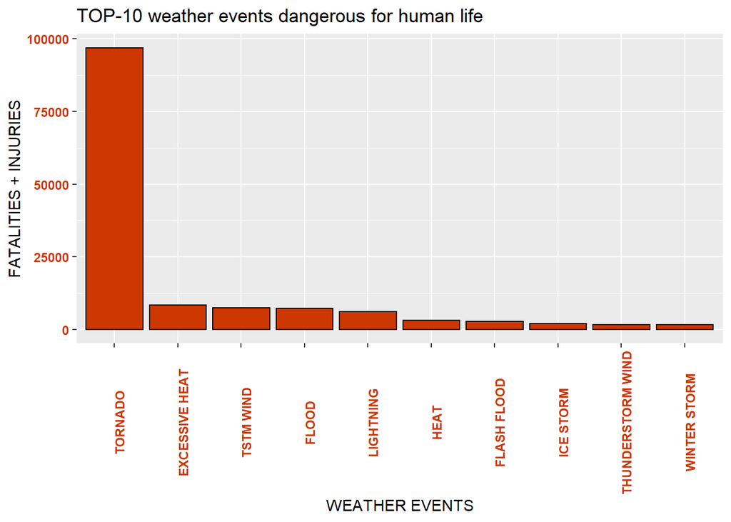

```r
ggplot(hd_data, aes(x = reorder(EVTYPE, -HEALTHDMG), y = HEALTHDMG)) +
        geom_bar(stat = "identity", color = "black", fill = "orangered3") +
        theme(axis.text.x = element_text(face = "bold", color = "orangered3", angle = 90),
              axis.text.y = element_text(face = "bold", color = "orangered3")) +
        labs(title = "TOP-10 weather events dangerous for human life", x = "WEATHER EVENTS", y = "FATALITIES + INJURIES")
```

#### **Question 2. Across the United States, which types of events have the greatest economic consequences?**

**For purpose of Question 2, we have to subset the data by selecting five columns**

```r
econdmg_data <- select(raw_data, EVTYPE,  PROPDMG, PROPDMGEXP, CROPDMG, CROPDMGEXP)
head(econdmg_data)
```

```
##    EVTYPE PROPDMG PROPDMGEXP CROPDMG CROPDMGEXP
## 1 TORNADO    25.0          K       0
## 2 TORNADO     2.5          K       0
## 3 TORNADO    25.0          K       0
## 4 TORNADO     2.5          K       0
## 5 TORNADO     2.5          K       0
## 6 TORNADO     2.5          K       0
```

**Check for NAs**

```r
  colSums(is.na(select(econdmg_data, PROPDMG, PROPDMGEXP, CROPDMG, CROPDMGEXP)))
```

```
##    PROPDMG PROPDMGEXP    CROPDMG CROPDMGEXP
##          0          0          0          0
```

**Show what kind of values store PROPDMGEXP and CROPDMGEXP**

```r
unique(econdmg_data$PROPDMGEXP) # unique values in PROPDMGEXP
```

```
##  [1] "K" "M" ""  "B" "m" "+" "0" "5" "6" "?" "4" "2" "3" "h" "7" "H" "-" "1" "8"
```

```r
unique(econdmg_data$CROPDMGEXP) # unique values in CROPDMGEXP
```

```
## [1] ""  "M" "K" "m" "B" "?" "0" "k" "2"
```

These alphabetical characters used to signify magnitude include “K” for thousands, “M” for millions, and “B” for billions.

| ExponentChar | ExponentMagnitude |
| --- | --- |
| B | 9 |
| M, m | 6 |
| K, k | 3 |
| H, h | 2 |
| 0, +, -, ? | 1 |
| "" | 0 |

**At first we need to replace alphabetical symbols replace with numeric and convert type of values to numeric.**

```r
# 1. PROPDMGEXP
econdmg_data <- econdmg_data %>% mutate(
        PROPDMGEXP = case_when(
         PROPDMGEXP == "K" ~ "3",
         PROPDMGEXP == "B" ~ "9",
         PROPDMGEXP %in% c("M", "m")  ~ "6",
         PROPDMGEXP %in% c("H", "h")  ~ "2",
         PROPDMGEXP %in% c("0", "+", "-", "?") ~ "1",
         PROPDMGEXP == "" ~ "0",
         TRUE ~ PROPDMGEXP)
        ) %>% mutate(PROPDMGEXP = as.numeric(PROPDMGEXP))

# 2. CROPDMGEXP
econdmg_data <- econdmg_data %>% mutate(
        CROPDMGEXP = case_when(
         CROPDMGEXP %in% c("K", "k") ~ "3",
         CROPDMGEXP == "B" ~ "9",
         CROPDMGEXP %in% c("M", "m")  ~ "6",
         CROPDMGEXP %in% c("0", "?") ~ "1",
         CROPDMGEXP == "" ~ "0",
         TRUE ~ CROPDMGEXP)
        ) %>% mutate(CROPDMGEXP = as.numeric(CROPDMGEXP))
```

**Now we should create another column ECONDMG and store in it sum of PROPDMG and CROPDMG**

```r
econdmg_data <- econdmg_data %>%
        mutate(ECONDMG = PROPDMG * 10^PROPDMGEXP + CROPDMG * 10^CROPDMGEXP) %>%
        select(EVTYPE, ECONDMG)
head(econdmg_data)
```

```
##    EVTYPE ECONDMG
## 1 TORNADO   25000
## 2 TORNADO    2500
## 3 TORNADO   25000
## 4 TORNADO    2500
## 5 TORNADO    2500
## 6 TORNADO    2500
```

**Next step is group data by weather event types, summarise and sort ECONDMG in descending order**

```r
econdmg_data <- econdmg_data %>%
        group_by(EVTYPE) %>%
        summarise(ECONDMG = sum(ECONDMG)) %>%
        arrange(desc(ECONDMG))
```

**Percentage of the TOP-10 amount in the total amount**

```r
percentage_of_top_10_econ_dmg <- sum(econdmg_data[1:10, "ECONDMG"])/sum(econdmg_data$ECONDMG)*100
```

**Total sum of TOP-10**

```r
total_sum_econ_dmg_top_10 <- sum(econdmg_data[1:10,"ECONDMG"])
```

**Select top 10 severe weather events which harmful to economic**

```r
econdmg_data_to_plot <- econdmg_data[1:10,]
print.data.frame(econdmg_data_to_plot)
```

```
##               EVTYPE      ECONDMG
## 1              FLOOD 150319678257
## 2  HURRICANE/TYPHOON  71913712800
## 3            TORNADO  57362337128
## 4        STORM SURGE  43323541000
## 5               HAIL  18761224287
## 6        FLASH FLOOD  18243993432
## 7            DROUGHT  15018672000
## 8          HURRICANE  14610229010
## 9        RIVER FLOOD  10148404500
## 10         ICE STORM   8967041810
```

**Constructing a graph to determine which severe weather events have the greatest economic consequences across the USA**

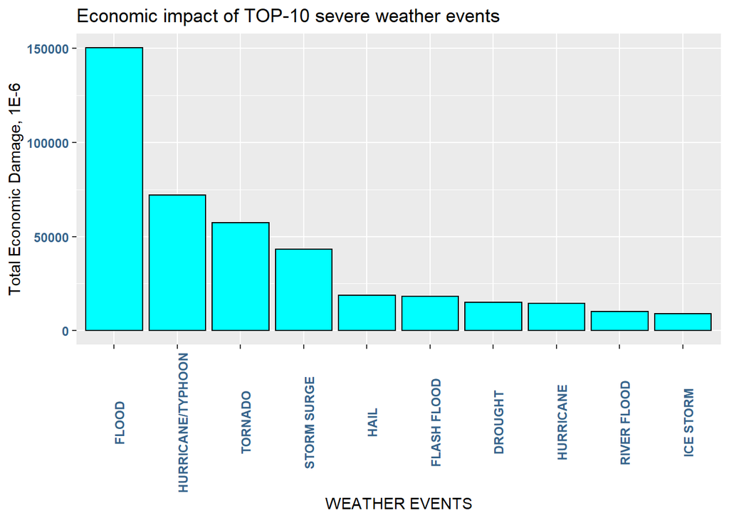

```r
ggplot(econdmg_data_to_plot, aes(x = reorder(EVTYPE, -ECONDMG), y = ECONDMG/1000000)) +
        geom_bar(stat = "identity", color = "black", fill = "cyan") +
        theme(axis.text.x = element_text(face = "bold", color = "steelblue4", angle = 90),
              axis.text.y = element_text(face = "bold", color = "steelblue4")) +
        labs(title = "Economic impact of TOP-10 severe weather events", x = "WEATHER EVENTS", y = "Total Economic Damage, 1E-6")
```

## Results

**The result of the analysis on question 1**. Analysis gives us the top-10 most harmful weather events (Tornado, Excessive Heat, TSTM wind, Flood, Lightining, Heat, Flash flood, Ice storm, Thunderstorm wind, Winter storm) to population health, and the total percentage of them in total amounts is **88.12%**. And most harmful from top-10 severe weather evets is **Tornado**.

**The result of the analysis on question 2**. There are Top-10 weather events which have the greatest economic consequences. Total amount of damage top-10 weather events is **408.67 Billion USD**. And the percentage of them in total amounts is **85.62%**. And finally we see that **Flood** is the greatest weather event which has big economic consequences across USA.